# Exploring the BRFSS data

## Setup

### Load packages

```r
library(ggplot2)
library(dplyr)
library(scales)
```

### Load data

```r
load("brfss2013.RData")
```

## Part 1: Data

First, this is an observational study since the CDC collected it by phone call. And since they conduct the survey to a random person in a household and those in private residence, it’s fair random sampling. However, the part of collecting data through the cellular phone are not. It’s based on the convenience. No ramdom assignment in this part. Therefore, the survey may not be representative to the population.

And the survey is mean to find the relation between behaviour about preventing diseases and unhealthy situations. Therefore, the explanatory variables are those preventive practices and the response variables are the diseases and injuries.

## Part 2: Research questions

**Research quesion 1:** How many people have personal doctors? And among them, how many are males and females? May indicates whether males or females are prone to have a personal doctor or more.

**Research quesion 2:** Do higher education or higher income indicate the habit of using seatbelt? Is the idea of using a seatbelt limit to better Socioeconomic status?

**Research quesion 3:** Do people correlate nervousness with mental unhealth? Even though we are not aware of that, we might subconsciously think being nervous is a kind of mental unhealthy.

## Part 3: Exploratory data analysis

**Research quesion 1:**

Q1. How many people have personal doctors? And among them, how many are males and females?

```r
addmargins(table(brfss2013$persdoc2,brfss2013$sex))
```

```
##
##                   Male Female    Sum
##   Yes, only one 140520 228534 369054
##   More than one  16034  25300  41334
##   No             43858  35726  79584
##   Sum           200412 289560 489972
```

```r
personal_doctor = brfss2013 %>%
  group_by(persdoc2, sex) %>%
  summarise(
    n = n()
  ) %>%
  na.omit(persdoc2) %>%
  mutate(pct = round(prop.table(n) * 100,2))
```

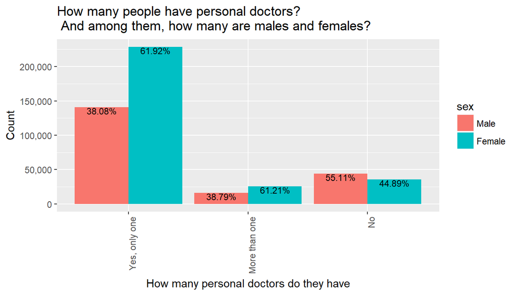

```r
ggplot(personal_doctor,aes(persdoc2,n,fill=sex)) +
  geom_bar(stat='identity', position = 'dodge') +
  geom_text(aes(x=persdoc2,y = n - 5000, label = paste0(pct, '%')),position = position_dodge(width = .9),size=3) +
  theme(axis.text.x = element_text(angle = 90, hjust = 1))+ ggtitle("How many people have personal doctors? \n And among them, how many are males and females?") +
  xlab("How many personal doctors do they have") + ylab("Count")+ scale_y_continuous(labels = comma)
```

```r
#The ratio of females with at least one doctor
n1 = 289560
pa = (228534+25300)/n1
print(pa)
```

```
## [1] 0.8766197
```

```r
#The ratio of males with at least one doctor
n2 = 200412
pb = (140520+16034)/n2
print(pb)
```

```
## [1] 0.7811608
```

We can see that there are more females having at least one personal doctor than males. Over 85% of females in the sample have at least one personal doctor, while, among males, there are about 78% of them have at least one personal doctor. Now, I won’t to do an AB testing to see if the difference is real.

H0: There is no difference between the proportion of males with at least a doctor and that of females H1: There is a significant difference between the proportion of males and females with at least a personal doctor.

```r
sea = (pa*(1-pa))/n1
seb = (pb*(1-pb))/n2
z2 = ((pa-pb)/sqrt(sea+seb))
1 - pnorm(abs(z2))
```

```
## [1] 0
```

**Research quesion 2:**

Do higher education or higher income indicate the habit of using seatbelt?

```r
addmargins(table(brfss2013$educa,brfss2013$seatbelt))
```

```
##
##                                                                Always
##   Never attended school or only kindergarten                      485
##   Grades 1 through 8 (Elementary)                               10089
##   Grades 9 though 11 (Some high school)                         20753
##   Grade 12 or GED (High school graduate)                       108211
##   College 1 year to 3 years (Some college or technical school) 106314
##   College 4 years or more (College graduate)                   143511
##   Sum                                                          389363
##
##                                                                Nearly always
##   Never attended school or only kindergarten                              28
##   Grades 1 through 8 (Elementary)                                        627
##   Grades 9 though 11 (Some high school)                                 1702
##   Grade 12 or GED (High school graduate)                               10625
##   College 1 year to 3 years (Some college or technical school)         10658
##   College 4 years or more (College graduate)                           10793
##   Sum                                                                  34433
##
##                                                                Sometimes
##   Never attended school or only kindergarten                          26
##   Grades 1 through 8 (Elementary)                                    501
##   Grades 9 though 11 (Some high school)                             1262
##   Grade 12 or GED (High school graduate)                            5247
##   College 1 year to 3 years (Some college or technical school)      3770
##   College 4 years or more (College graduate)                        2874
##   Sum                                                              13680
##
##                                                                Seldom
##   Never attended school or only kindergarten                        7
##   Grades 1 through 8 (Elementary)                                 165
##   Grades 9 though 11 (Some high school)                           445
##   Grade 12 or GED (High school graduate)                         2180
##   College 1 year to 3 years (Some college or technical school)   1734
##   College 4 years or more (College graduate)                     1164
##   Sum                                                            5695
##
##                                                                 Never
##   Never attended school or only kindergarten                       20
##   Grades 1 through 8 (Elementary)                                 387
```

[output cut: 8 more lines]

```
##   Grades 1 through 8 (Elementary)                                                       178
##   Grades 9 though 11 (Some high school)                                                 200
##   Grade 12 or GED (High school graduate)                                                352
##   College 1 year to 3 years (Some college or technical school)                          199
##   College 4 years or more (College graduate)                                            181
##   Sum                                                                                  1125
##
##                                                                   Sum
##   Never attended school or only kindergarten                      581
##   Grades 1 through 8 (Elementary)                               11947
##   Grades 9 though 11 (Some high school)                         25154
##   Grade 12 or GED (High school graduate)                       129630
##   College 1 year to 3 years (Some college or technical school) 124597
##   College 4 years or more (College graduate)                   159809
##   Sum                                                          451718
```

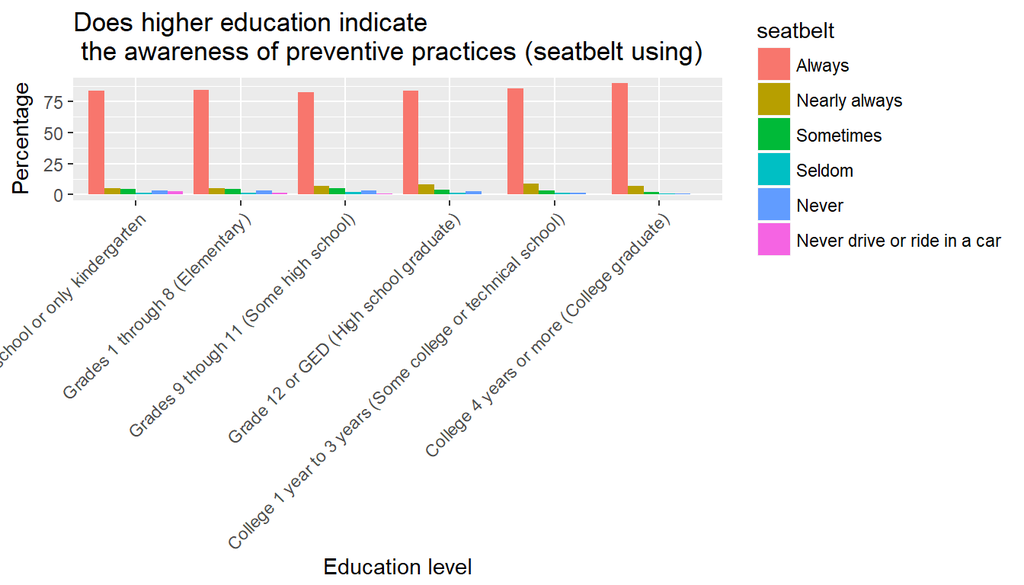

```r
education_seatbelt = brfss2013 %>%
  select(educa,seatbelt) %>%
  filter(!(educa =="NA's" | seatbelt =="NA's")) %>%
  group_by(educa,seatbelt) %>%
  summarise(
    n = n()
  ) %>%
  mutate(pct = round(prop.table(n) * 100,2))

ggplot(education_seatbelt,aes(educa,pct,fill=seatbelt)) + geom_bar(stat='identity', position = 'dodge') +
  theme(axis.text.x = element_text(angle = 45, hjust = 1))+ ggtitle("Does higher education indicate \n the awareness of preventive practices (seatbelt using)") +
  xlab("Education level") + ylab("Percentage")+ scale_y_continuous(labels = comma)
```

It seems that the habit of using seatbelt doesn’t have too much thing to do with the education level. Most of the citizens do use the seatbelt in their life.

```r
addmargins(table(brfss2013$income2,brfss2013$seatbelt))
```

```
##
##                     Always Nearly always Sometimes Seldom  Never
##   Less than $10,000  19333          1497       990    368    689
##   Less than $15,000  20567          1728      1046    365    670
##   Less than $20,000  26791          2369      1310    507    742
##   Less than $25,000  32557          2946      1381    591    831
##   Less than $35,000  38385          3782      1558    643    849
##   Less than $50,000  48862          5103      1827    777    938
##   Less than $75,000  52944          5315      1624    733    747
##   $75,000 or more    97275          7887      2136   1018    987
##   Sum               336714         30627     11872   5002   6453
##
##                     Never drive or ride in a car    Sum
##   Less than $10,000                          252  23129
##   Less than $15,000                          167  24543
##   Less than $20,000                          120  31839
##   Less than $25,000                          102  38408
##   Less than $35,000                           73  45290
##   Less than $50,000                           45  57552
##   Less than $75,000                           37  61400
##   $75,000 or more                             45 109348
##   Sum                                        841 391509
```

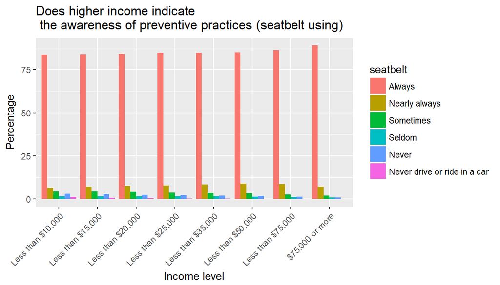

```r
income_seatbelt = brfss2013 %>%
  select(income2,seatbelt) %>%
  filter(!(income2 =="NA's" | seatbelt =="NA's")) %>%
  group_by(income2,seatbelt) %>%
  summarise(
    n = n()
  ) %>%
  mutate(pct = round(prop.table(n) * 100,2))

ggplot(income_seatbelt,aes(income2,pct,fill=seatbelt)) + geom_bar(stat='identity', position = 'dodge') +
  theme(axis.text.x = element_text(angle = 45, hjust = 1))+ ggtitle("Does higher income indicate \n the awareness of preventive practices (seatbelt using)") +
  xlab("Income level") + ylab("Percentage")+ scale_y_continuous(labels = comma)
```

There isn’t too much correlation between income level and the habit of using seatbelt. In each income level, over 75% of the people always use seatbelt.

**Research quesion 3:** Do people correlate nervousness with mental unhealth?

```r
nervous_unhealth = brfss2013 %>%
  select(misnervs,menthlth) %>%
  filter(!(misnervs =="NA's" | menthlth > 60)) %>%
  group_by(misnervs) %>%
  summarise(
    mean_unhealth_day = round(mean(menthlth),2),
    median_unhealth_day = round(median(menthlth),2),
    n = n()
  ) %>%
  mutate(pct = round(prop.table(n) * 100,2))
nervous_unhealth
```

```
## # A tibble: 5 x 5
##   misnervs mean_unhealth_day median_unhealth_day     n   pct
##   <fct>                <dbl>               <dbl> <int> <dbl>
## 1 All                  17.2                20.0    794  2.23
## 2 Most                 15.1                15.0   1237  3.47
## 3 Some                  6.52                2.00  5154 14.5
## 4 A little              2.62                0    10615 29.8
## 5 None                  1.18                0    17847 50.1
```

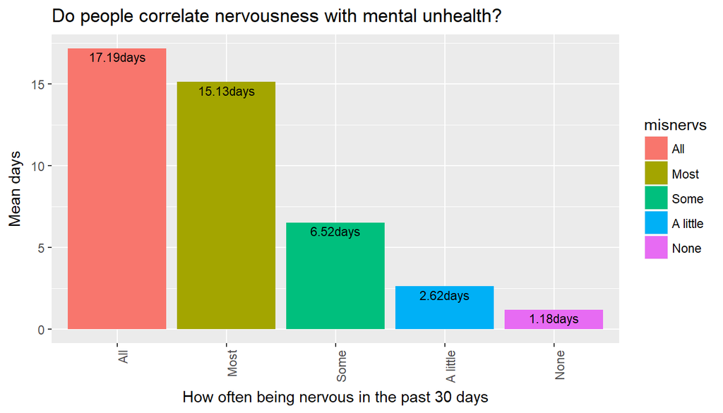

```r
ggplot(nervous_unhealth,aes(misnervs,mean_unhealth_day,fill=misnervs)) +
  geom_bar(stat='identity', position = 'dodge') +
  geom_text(aes(x=misnervs,y = mean_unhealth_day - 0.5, label = paste0(mean_unhealth_day, 'days')),position = position_dodge(width = .9),size=3) +
  theme(axis.text.x = element_text(angle = 90, hjust = 1))+ ggtitle("Do people correlate nervousness with mental unhealth?") +
  xlab("How often being nervous in the past 30 days") + ylab("Mean days")+ scale_y_continuous(labels = comma)
```

It’s true that people with more frequently nervous have more mental unhealthy days. So I believe that people think nervous too much are some kinds of mental unhealth,too. Even though, in my own opinion, being nervous seems normal in our daily life, it may indicates unhealth of our mental.